# OMICsPCA: An R package for quantitative integration and analysis of multiple omics assays from heterogeneous samples

## 3.11 Cluster Analysis

The principal components obtained by combining multiple assays represent the overall epigenetic state of each annotation (here TSSs). Our next objective is to find out groups of similar TSSs in terms of the combined epigenetic state. We will use a suitable clustering technique(s) to accomplish this job.

There are various clustering techniques available, each is designed to perform specific tasks. Most of the partition based clustering algorithms need the number of clusters as an input. From our density analysis, we observed two dense regions in the data space of PC1 and PC2. This suggests that the number of clusters should be set at 2. However, there are sophisticated indices designed to validate the number of clusters.

OMICsPCA has a function “cluster_parameters()” to perform this job. It runs two algorithms “clvalid” and “NbClust” in the background, which in turn use different sets of validation techniques to decide the number of clusters.

“cluster_parameters()” extracts data from the “OMICs” object supplied through `name` argument via the “extract()” function. Both the algorithms used in “cluster_parameters()” function takes huge memory and CPU for a higher number of samples. Therefore, it is recommended to use a subset of original data while running this function. A subset of rows can be selected randomly through the `rand` argument of “extract()”. The user may also choose whether to use integrated assays or nonintegrated assays through the logical argument `integrated` of the function “extract()”.

```r
data <- extract(name = "OMICsdata", PC = c(1:4),
groups = c("WE","RE"), integrated = TRUE, rand = 600)
```

“cluster_parameters()” uses the output of “extract()” and runs one of the algorithms between “clvalid” or “NbClust” to determine the number of clusters.

The parameters of “clvalid” and “NbClust” are passed through the `clusteringMethods`, `validationMethods` and `distance` argument of “cluster_parameters()” function. The argument pairs are different in “NbClust” and “clvalid” and thus should be chosen carefully.

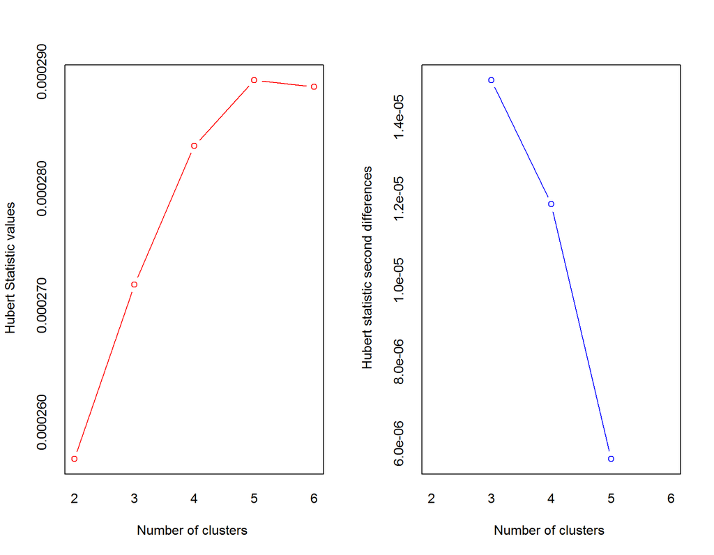

```
# *** : The Hubert index is a graphical method of determining the number of clusters.
#                 In the plot of Hubert index, we seek a significant knee that corresponds to a
#                 significant increase of the value of the measure i.e the significant peak in Hubert
#                 index second differences plot.
#
```

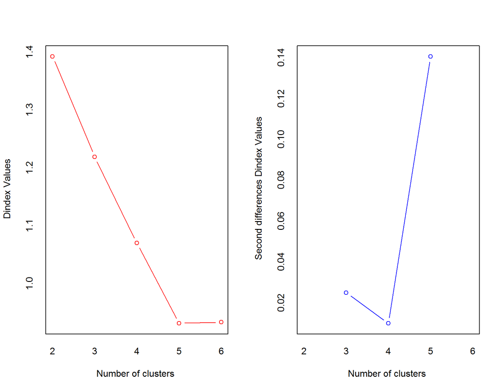

```
# *** : The D index is a graphical method of determining the number of clusters.
#                 In the plot of D index, we seek a significant knee (the significant peak in Dindex
#                 second differences plot) that corresponds to a significant increase of the value of
#                 the measure.
#
# *******************************************************************
# * Among all indices:
# * 8 proposed 2 as the best number of clusters
# * 6 proposed 3 as the best number of clusters
# * 1 proposed 4 as the best number of clusters
# * 6 proposed 5 as the best number of clusters
# * 2 proposed 6 as the best number of clusters
#
#                    ***** Conclusion *****
#
# * According to the majority rule, the best number of clusters is  2
#
#
# *******************************************************************

library(factoextra)
# Welcome! Related Books: `Practical Guide To Cluster Analysis in R` at https://goo.gl/13EFCZ

fviz_nbclust(clusterstats, method = c("silhouette",
"wss", "gap_stat"))
# Among all indices:
# ===================
# * 2 proposed  0 as the best number of clusters
# * 8 proposed  2 as the best number of clusters
# * 6 proposed  3 as the best number of clusters
# * 1 proposed  4 as the best number of clusters
# * 6 proposed  5 as the best number of clusters
# * 2 proposed  6 as the best number of clusters
# * 1 proposed  NA's as the best number of clusters
#
# Conclusion
# =========================
# * According to the majority rule, the best number of clusters is  2 .
```

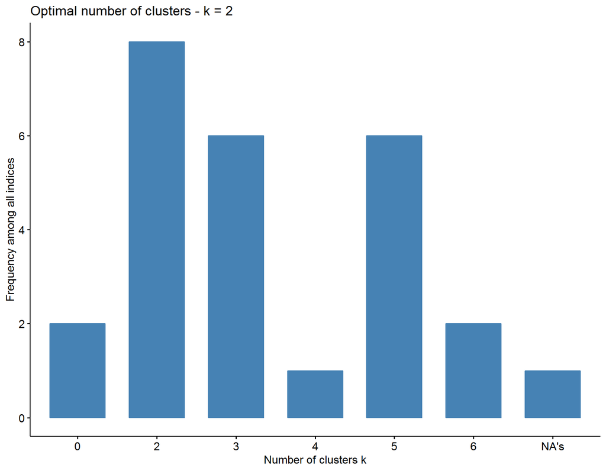

```r
#### Using "clValid" ####

clusterstats <- cluster_parameters(name = data,
optimal = FALSE, n = 2:6, comparisonAlgorithm = "clValid",
distance = "euclidean", clusteringMethods = c("kmeans","pam"),
validationMethods = c("internal","stability"))
#
# Clustering Methods:
#  kmeans pam
#
# Cluster sizes:
#  2 3 4 5 6
#
# Validation Measures:
#                            2       3       4       5       6
#
# kmeans APN            0.0476  0.0624  0.1447  0.1591  0.1408
#        AD             2.2430  1.9829  1.8132  1.5971  1.4922
#        ADM            0.7232  0.7994  0.8197  0.7502  0.6803
#        FOM            1.4115  1.3704  1.2706  1.1599  1.1175
#        Connectivity  29.5405 50.8714 73.2397 88.6615 95.1040
#        Dunn           0.1190  0.0788  0.0863  0.0687  0.0626
#        Silhouette     0.7429  0.6925  0.6655  0.6421  0.6439
# pam    APN            0.0565  0.1009  0.1506  0.1992  0.2180
#        AD             2.2294  1.9259  1.7058  1.6408  1.5523
#        ADM            0.7311  0.7683  0.7217  0.9137  0.8642
#        FOM            1.4050  1.3217  1.1790  1.1527  1.1588
#        Connectivity  24.9313 50.3837 94.1881 96.7266 90.3099
#        Dunn           0.0911  0.0788  0.0758  0.0309  0.0222
#        Silhouette     0.7425  0.6927  0.6450  0.5704  0.5872
#
# Optimal Scores:
#
#              Score   Method Clusters
# APN           0.0476 kmeans 2
# AD            1.4922 kmeans 6
# ADM           0.6803 kmeans 6
# FOM           1.1175 kmeans 6
# Connectivity 24.9313 pam    2
# Dunn          0.1190 kmeans 2
# Silhouette    0.7429 kmeans 2

#### plot indexes vs cluster numbers returned by clValid
#plot(clusterstats)


#### using "NbClust"

path <- system.file("extdata/groupinfo",
package = "OMICsPCAdata")

data <- extract(name = "OMICsdata", PC = c(1:4),
groups = c("WE","RE"),integrated = TRUE, rand = 400)

clusterstats <- cluster_parameters(name = data, n = 2:6,
comparisonAlgorithm = "NbClust", distance = "euclidean",
clusteringMethods = "kmeans",
validationMethods = "all")
# [1] "Frey index : No clustering structure in this data set"
```

Now, depending on the output of “cluster_parameters()”, we may choose the appropriate clustering algorithm and number of clusters.

OMICsPCA has a function “cluster()” that is designed for the clustering task. “cluster()” has many clustering options which should be chosen through `choice` argument. The class of the returned value by “cluster()” depends on the type of clustering method chosen. So, extraction and visualization of data from cluster objects are different for different choices.

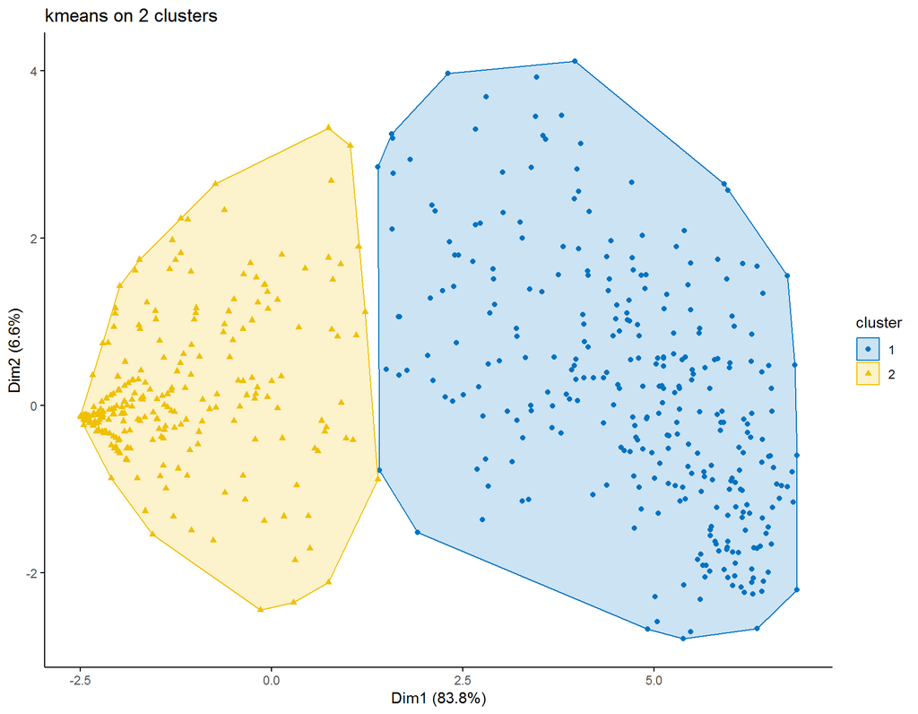

```r
data <- extract(name = "OMICsdata", PC = c(1:4),
groups = c("WE","RE"), integrated = TRUE, rand = 1000)

library(factoextra)

### kmeans clustering

clusters <- cluster(name = data, n = 2, choice = "kmeans",
title = "kmeans on 2 clusters")

# visualization of clusters

print(clusters$plot)
```

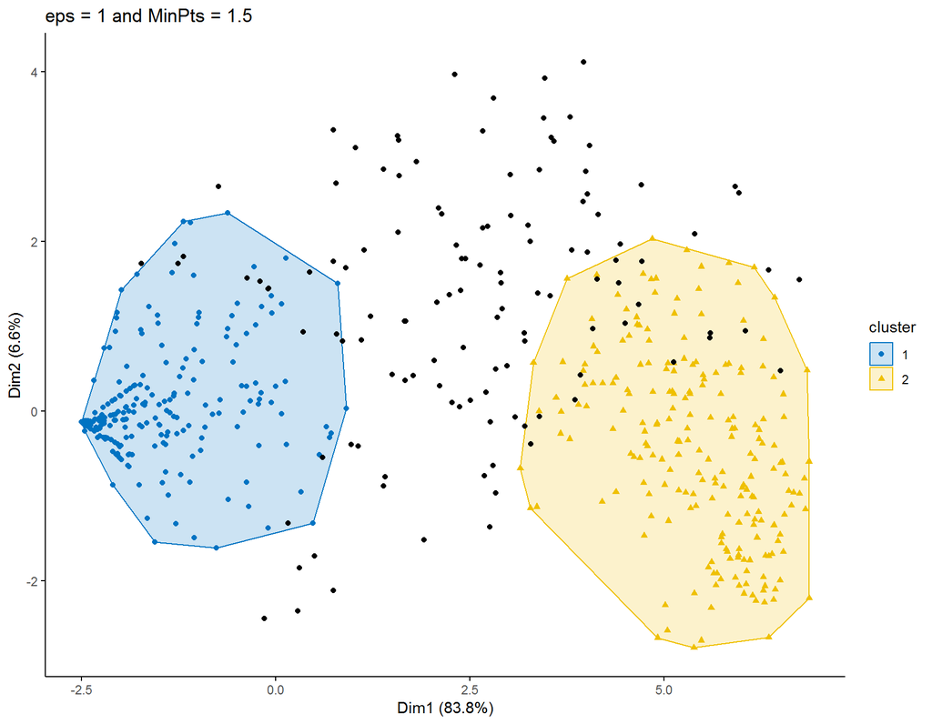

```r
# in 3D
clustered_data <- cbind(data,clusters$cluster$cluster)
plot3d(data[,1:3], col = clusters$cluster$cluster)

### density-based clustering

clusters <- cluster(name = data, choice = "density",
eps = 2, MinPts = 100, graph = TRUE,
title = "eps = 1 and MinPts = 1.5")

# visualization of clusters
print(clusters$plot)
```

```r
# in 3D
clustered_data <- as.data.frame(cbind(data,clusters$cluster$cluster))

#removing unclustered points
clustered_data <- clustered_data[clustered_data$V5 != 0, ]

library(rgl)
#plotting clusters on first 3 PCs
plot3d(clustered_data[,1:3], col = clustered_data$V5)
```

### 3.11.1 Validation of clusters

```r
#### Using silhouette index
# calculating the distance matrix
library(cluster)
dist <- daisy(data)

sil = silhouette(clusters$cluster$cluster,dist)

# RStudio sometimes does not display silhouette plots
#correctly. So sometimes, it is required to plot in separate
#window.

#grDevices::windows()
#plot(sil)
```

### 3.11.2 Identification of misclassified points

```r
# Identification of misclassified data points
# silhouette width of misclassified points are negative
misclassified <- which(sil[,3] < 0)

head(sil[misclassified,])
#      cluster neighbor   sil_width
# [1,]       0        1 -0.25053896
# [2,]       0        2 -0.02688910
# [3,]       0        2 -0.21690467
# [4,]       0        2 -0.05874253
# [5,]       0        1 -0.27120794
# [6,]       0        1 -0.05119546

data[misclassified[3:7],]
#                                                           Dim.1      Dim.2
# ENST00000530413.1                                     3.3693995 -0.8623673
# ENST00000506591.1                                     2.8425004 -0.4222208
# ENST00000449882.2                                     0.1719509 -0.6119710
# ENST00000358470.4;ENST00000432798.1;ENST00000450994.1 0.3755849  1.6720099
# ENST00000431824.2                                     3.8648261  0.2347660
#                                                            Dim.3
# ENST00000530413.1                                     -2.5861800
# ENST00000506591.1                                      1.8538528
# ENST00000449882.2                                      2.5297243
# ENST00000358470.4;ENST00000432798.1;ENST00000450994.1  1.2648318
# ENST00000431824.2                                      0.9150167
#                                                            Dim.4
# ENST00000530413.1                                      0.7206653
# ENST00000506591.1                                      0.2879993
# ENST00000449882.2                                     -0.3307039
# ENST00000358470.4;ENST00000432798.1;ENST00000450994.1  3.4139413
# ENST00000431824.2                                     -1.9487824
```

We may reorganize the misclassified points into appropriate clusters.

### 3.11.3 Exploration of clusters

let’s explore the clusters more

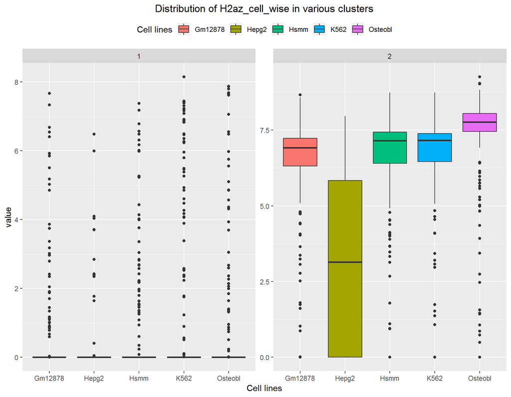

```r
bp <- cluster_boxplot(name = "OMICsdata",
Assay = "H2az_Cell_wise", clusterobject = clustered_data,
clustercolumn = 5)

#library(ggplot2)

bp <- bp+xlab("Cell lines") + ylab(
    "value")+ggtitle(
    "Distribution of H2az_cell_wise in various clusters")+theme(
    plot.title=element_text(hjust=0.5),
    legend.position = "top")+guides(
    fill=guide_legend("Cell lines"))

bp
```

The overall distribution of H2az is significantly different in the two clusters, implying a good clustering by density based. This process may be applied to other factors or other clustering methods.

# 4 Summary

Most of the multi-omics data integration algorithms are focused on 2 applications:

1. use of integrated data for class prediction (e.g. identification of diseased individuals) and
2. analysis of the source of variation across samples and individuals.

However, such approaches do not suffice to other potential applications including quantitative representation of the combined effect of multiple data modalities, clustering of individuals on the basis of combined epigenetic state etc. We propose here a new tool OMICsPCA, designed for integrative analysis of multi-omics data including the ones mentioned above.

Integration of multi-omics data involves 2 major tasks:

1. analysis of the source of variation among the samples of a data modality and
2. calculation of the combined effect of multiple data modalities on the individuals.

We used a **3 step process** to analyse the variation among the samples of each data modality. **First**, we used **descriptor()** and **chart_correlation()** to get an initial clue about the overall nature of the samples. **Second**, we used **integrate_variables()**, **analyse_variables()** and **analyse_individuals()** to dissect the variation among the samples of a modality, as well as the individuals in a group-wise manner. **Third**, we used density analysis to study the internal structure of the data distribution which in turn used to identify the “discriminatory data modalities” or assays that show different density structures in different groups of individuals. These 3 step process is used to study the difference between the groups of individuals and to select the similar samples corresponding to a data modality.

In the second task, we linearly combined all the similar samples corresponding to the selected factors (these may be the discriminatory factors) using Principal Component Analysis (PCA). Each of the Principal components represents the combined state of various data modalities across multiple samples. We used these combined metrices to identify similar individuals (TSSs) by various clustering methods.

OMICsPCA overcomes the limitations of the existing tools and has a good potential to be used as an multipurpose data integration and analysis tool.

# 5 SessionInfo

```r
sessionInfo()
# R version 3.5.0 (2018-04-23)
# Platform: x86_64-w64-mingw32/x64 (64-bit)
# Running under: Windows 7 x64 (build 7601) Service Pack 1
#
# Matrix products: default
#
# locale:
# [1] LC_COLLATE=English_India.1252  LC_CTYPE=English_India.1252
# [3] LC_MONETARY=English_India.1252 LC_NUMERIC=C
# [5] LC_TIME=English_India.1252
#
# attached base packages:
# [1] parallel  stats4    stats     graphics  grDevices utils     datasets
# [8] methods   base
#
# other attached packages:
#  [1] factoextra_1.0.5      ggplot2_3.0.0         DOSE_3.6.1
#  [4] org.Hs.eg.db_3.6.0    AnnotationDbi_1.42.1  IRanges_2.14.10
#  [7] S4Vectors_0.18.3      Biobase_2.40.0        BiocGenerics_0.26.0
# [10] clusterProfiler_3.8.1 pdftools_1.8          magick_1.9
# [13] fpc_2.1-11            cluster_2.0.7-1       rgl_0.99.16
# [16] knitr_1.20            rmarkdown_1.10        kableExtra_0.9.0
# [19] OMICsPCAdata_0.99.1   OMICsPCA_0.99.0
#
# loaded via a namespace (and not attached):
#   [1] backports_1.1.2             fastmatch_1.1-0
#   [3] corrplot_0.84               igraph_1.2.2
#   [5] plyr_1.8.4                  lazyeval_0.2.1
#   [7] splines_3.5.0               BiocParallel_1.14.1
#   [9] crosstalk_1.0.0             GenomeInfoDb_1.16.0
#  [11] digest_0.6.15               GOSemSim_2.6.0
#  [13] htmltools_0.3.6             viridis_0.5.1
#  [15] GO.db_3.6.0                 magrittr_1.5
#  [17] memoise_1.1.0               BSgenome_1.48.0
#  [19] Biostrings_2.48.0           readr_1.1.1
#  [21] matrixStats_0.53.1          docopt_0.4.5
#  [23] xts_0.10-2                  enrichplot_1.0.2
#  [25] prettyunits_1.0.2           colorspace_1.3-2
#  [27] blob_1.1.1                  rvest_0.3.2
#  [29] ggrepel_0.8.0               HelloRanges_1.6.0
#  [31] dplyr_0.7.5                 crayon_1.3.4
#  [33] RCurl_1.95-4.10             jsonlite_1.5
#  [35] bindr_0.1.1                 VariantAnnotation_1.26.0
#  [37] zoo_1.8-2                   glue_1.2.0
#  [39] gtable_0.2.0                zlibbioc_1.26.0
#  [41] XVector_0.20.0              UpSetR_1.3.3
#  [43] webshot_0.5.0               DelayedArray_0.6.1
#  [45] kernlab_0.9-26              prabclus_2.2-6
#  [47] DEoptimR_1.0-8              scales_0.5.0
#  [49] mvtnorm_1.0-8               DBI_1.0.0
#  [51] miniUI_0.1.1.1              Rcpp_0.12.17
#  [53] viridisLite_0.3.0           xtable_1.8-2
#  [55] progress_1.2.0              units_0.6-0
#  [57] flashClust_1.01-2           bit_1.1-14
#  [59] mclust_5.4.1                htmlwidgets_1.2
#  [61] httr_1.3.1                  fgsea_1.6.0
#  [63] modeltools_0.2-21           pkgconfig_2.0.1
#  [65] XML_3.98-1.11               flexmix_2.3-14
#  [67] nnet_7.3-12                 utf8_1.1.4
#  [69] labeling_0.3                tidyselect_0.2.4
#  [71] rlang_0.2.1                 manipulateWidget_0.10.0
#  [73] reshape2_1.4.3              later_0.7.3
#  [75] munsell_0.5.0               tools_3.5.0
#  [77] cli_1.0.0                   RSQLite_2.1.1
#  [79] ggridges_0.5.0              evaluate_0.10.1
#  [81] stringr_1.3.1               yaml_2.1.19
#  [83] bit64_0.9-7                 robustbase_0.93-1
#  [85] purrr_0.2.5                 ggraph_1.0.2
#  [87] bindrcpp_0.2.2              mime_0.5
#  [89] DO.db_2.9                   leaps_3.0
#  [91] xml2_1.2.0                  biomaRt_2.36.1
#  [93] compiler_3.5.0              rstudioapi_0.7
#  [95] png_0.1-7                   tweenr_0.1.5
#  [97] tibble_1.4.2                stringi_1.1.7
#  [99] highr_0.7                   GenomicFeatures_1.32.0
# [101] lattice_0.20-35             trimcluster_0.1-2
# [103] Matrix_1.2-14               ggsci_2.9
# [105] pillar_1.2.3                data.table_1.11.4
# [107] cowplot_0.9.3               bitops_1.0-6
# [109] qvalue_2.12.0               httpuv_1.4.4.1
# [111] rtracklayer_1.40.3          GenomicRanges_1.32.3
# [113] R6_2.2.2                    promises_1.0.1
# [115] gridExtra_2.3               MASS_7.3-49
# [117] assertthat_0.2.0            SummarizedExperiment_1.10.1
# [119] rprojroot_1.3-2             withr_2.1.2
# [121] GenomicAlignments_1.16.0    Rsamtools_1.32.0
# [123] GenomeInfoDbData_1.1.0      PerformanceAnalytics_1.5.2
# [125] diptest_0.75-7              hms_0.4.2
# [127] quadprog_1.5-5              grid_3.5.0
# [129] tidyr_0.8.1                 NbClust_3.0
# [131] class_7.3-14                rvcheck_0.1.0
# [133] clValid_0.6-6               ggpubr_0.1.7
# [135] ggforce_0.1.3               scatterplot3d_0.3-41
# [137] shiny_1.1.0                 FactoMineR_1.41
```

# 6 References

1. Huang YT. Integrative modeling of multiple genomic data from different types of genetic association studies. Biostatistics. 2014 Oct;15(4):587-602. PubMed PMID: 24705142.
2. He X, Fuller CK, Song Y, Meng Q, Zhang B, Yang X, et al. Sherlock: detecting gene-disease associations by matching patterns of expression QTL and GWAS. American journal of human genetics. 2013 May 2;92(5):667-80. PubMed PMID: 23643380. Pubmed Central PMCID: 3644637.
3. Xiong Q, Ancona N, Hauser ER, Mukherjee S, Furey TS. Integrating genetic and gene expression evidence into genome-wide association analysis of gene sets. Genome research. 2012 Feb;22(2): 386-97. PubMed PMID: 21940837. Pubmed Central PMCID: 3266045.
4. Ha M, Hong S. Gene-regulatory interactions in embryonic stem cells represent cell-type specific gene regulatory programs. Nucleic acids research. 2017 Oct 13;45(18):10428-35. PubMed PMID: 28977540. Pubmed Central PMCID: 5737473.
5. Chen L, Ge B, Casale FP, Vasquez L, Kwan T, Garrido-Martin D, et al. Genetic Drivers of Epigenetic and Transcriptional Variation in Human Immune Cells. Cell. 2016 Nov 17;167(5):1398-414 e24. PubMed PMID: 27863251. Pubmed Central PMCID: 5119954.
6. Consortium GT. Human genomics. The Genotype-Tissue Expression (GTEx) pilot analysis: multitissue gene regulation in humans. Science. 2015 May 8;348(6235):648-60. PubMed PMID: 25954001. Pubmed Central PMCID: 4547484.
7. Lanckriet GR, De Bie T, Cristianini N, Jordan MI, Noble WS. A statistical framework for genomic data fusion. Bioinformatics. 2004 Nov 1;20(16):2626-35. PubMed PMID: 15130933.
8. Wang B, Mezlini AM, Demir F, Fiume M, Tu Z, Brudno M, et al. Similarity network fusion for aggregating data types on a genomic scale. Nature methods. 2014 Mar;11(3):333-7. PubMed PMID: 24464287.
9. Argelaguet R, Velten B, Arnol D, Dietrich S, Zenz T, Marioni JC, et al. Multi-Omics Factor Analysis-a framework for unsupervised integration of multi-omics data sets. Molecular systems biology. 2018 Jun 20;14(6):e8124. PubMed PMID: 29925568. Pubmed Central PMCID: 6010767.